# PAWS Analysis with R-Ladies - Exploring and Manipulating the Data

Alice Walsh (updated by KF)

8/20/2018

```r
# This code works when you are using RStudio project. Paths are relative and stuff
suppressPackageStartupMessages(library(tidyverse))
library(ggalluvial)
```

# Question

What is the typical pattern for volunteer disengagement?

# Procedure

- We have data from orientation sign up - orientation dates
- We have data from PAWS master volunteer database - date for when they were entered and then started
- We have data from volunteer shifts when people logged in and logged out
1. Load in the data
2. Process data to make it analysis-ready
3. Do some data exploration
4. Make a plot to show volunteer patterns
5. Idea: use ggplot2 extension ggalluvial

This Rmd contains data cleaning code and some initial plots. The final_report_q3.Rmd has the analysis that uses the output from this file.

## Load Data

```r
master_file <- '../../../Data/master.csv'
service_file <- '../../../Data/service.csv'
signup_file <- '../../../Data/signupsheet.csv'

master <- read.csv(master_file, quote="", stringsAsFactors = F)
service <- read.csv(service_file, stringsAsFactors = F)
signup <- read.csv(signup_file, stringsAsFactors = F)
```

The ../../../Data/master.csv has 1238 rows.

The ../../../Data/service.csv has 26458 rows.

The ../../../Data/signupsheet.csv has 800 rows.

### Basic info on signup table

Signup table has information of the types of orientations.

```r
knitr::kable(table(signup$Type, exclude=NULL), caption = "Type")
```

Type

| Var1 | Freq |
| --- | --- |
| GF Basic | 85 |
| GF Basic | 1 |
| GF Basic + GF WD | 2 |
| GF Basic + GF WD | 144 |
| GF WD | 16 |
| NE | 165 |
| NE + NE | 1 |
| PAC Cat | 311 |
| PAC Dog | 75 |

```r
knitr::kable(table(signup$NOT.Attending, exclude=NULL), caption = "Not Attending")
```

Not Attending

| Var1 | Freq |
| --- | --- |
|  | 799 |
| CANCELLED | 1 |

```r
knitr::kable(table(signup$Present, exclude=NULL), caption = "Present")
```

Present

| Var1 | Freq |
| --- | --- |
| PRESENT | 800 |

```r
knitr::kable(table(signup$orientation, exclude=NULL), caption = "Primary or Secondary Orientation")
```

Primary or Secondary Orientation

| Var1 | Freq |
| --- | --- |
| Primary | 736 |
| Secondary | 64 |

OK, so I learned that we need to clean up with “Type” fields and remove one row for cancelling on the orientation.

I also created a orientation location that was separate from orientation type.

```r
signup_clean <- signup %>%
  filter(NOT.Attending != "CANCELLED") %>%
  mutate(Type = case_when(
    Type == "NE" | Type == "NE + NE" ~ "NE Basic",
    Type == "GF Basic " ~ "GF Basic",
    Type == "GF Basic  + GF WD" ~ "GF Basic + WD",
    Type == "GF Basic + GF WD" ~ "GF Basic + WD",
    TRUE ~ as.character(Type)
  )) %>%
  separate(Type, into = c("orient_loc", "orient_type"), sep = " ", extra = "merge", remove = FALSE) %>%
  select(-NOT.Attending, -Present) %>% # dont need these
  mutate(Orientation.Date = as.Date(Orientation.Date, format = "%m/%d/%y")) %>%
  arrange(Orientation.Date)
with(signup_clean, table(orient_type, orientation, exclude = NULL) )
```

```
##             orientation
## orient_type  Primary Secondary
##   Basic          238        14
##   Basic + WD     135        11
##   Cat            293        18
##   Dog             58        17
##   WD              11         4
```

```r
with(signup_clean, table(orient_loc, orientation, exclude = NULL) )
```

```
##           orientation
## orient_loc Primary Secondary
##        GF      224        23
##        NE      160         6
##        PAC     351        35
```

The earliest orientation date was 2017-01-08

Decided to make separate variables for Primary and Secondary orientation (convert to wide). There were some cases where there were duplicate Secondary orientations for a single ID. Kept the earliest.

```r
signup_clean <- reshape(signup_clean,timevar="orientation",idvar="ID",direction="wide")
```

It is known that there are a handful of cases where Primary occured after Secondary orientation - swap those.

```r
signup_clean <- signup_clean %>%
  mutate(sec_prim = Orientation.Date.Secondary - Orientation.Date.Primary) %>%
  mutate(new.Date.Primary = case_when(
    sec_prim < 0 ~ Orientation.Date.Secondary,
    TRUE ~ Orientation.Date.Primary
  ),
  new.Date.Secondary = case_when(
    sec_prim < 0 ~Orientation.Date.Primary,
    TRUE ~ Orientation.Date.Secondary
  )) %>%
  mutate(sec_prim_new = new.Date.Secondary - new.Date.Primary) %>%
  select( -Orientation.Date.Primary, -Orientation.Date.Secondary, -sec_prim ) %>%
  rename(Orientation.Date.Primary= new.Date.Primary, Orientation.Date.Secondary= new.Date.Secondary)
```

### Basic info on master table

Can see that again the text fields like city are not clean.

I cleaned the City variable and converted all zip code to 5 digit level. The zip codes are still messed up as some are not valid 5-digit codes. They might be missing a leading zero.

```r
master_clean <- master %>%
  mutate(city_clean = case_when(
    grepl("Phil|phil", City) ~ "Philadelphia",
    TRUE ~ "other"
  ),
  Zip = case_when(
    grepl("PA|NJ", Zip) ~ "",
    TRUE ~ as.character(Zip)
  )) %>%
  separate(Zip, into="Zip", sep="-", extra = "drop")
```

```r
knitr::kable(table(master_clean$Status, exclude=NULL), caption = "Status")
```

Status

| Var1 | Freq |
| --- | --- |
| Active | 1234 |
| Applicant | 1 |
| Inactive | 2 |
| Prospect | 1 |

```r
knitr::kable(table(master_clean$city_clean, exclude=NULL), caption = "City after cleaning")
```

City after cleaning

| Var1 | Freq |
| --- | --- |
| other | 298 |
| Philadelphia | 940 |

```r
# knitr::kable(table(master_clean$Zip, exclude=NULL), caption = "Zip Codes after cleaning")
```

Look at the date ranges for the dates

```r
master_clean <- master_clean %>%
  mutate(Date.entered = as.Date(Date.entered, format = "%m-%d-%Y"),
         Start.date = as.Date(Start.date, format = "%m-%d-%Y"),
         Stop.date = as.Date(Stop.date, format = "%m-%d-%Y"),
         Orientation.Date.master = as.Date(Orientation.Date, format = "%m-%d-%Y"))

print("Date.entered")
```

```
## [1] "Date.entered"
```

```r
summary(master_clean$Date.entered)
```

```
##         Min.      1st Qu.       Median         Mean      3rd Qu.
## "2012-08-13" "2017-01-19" "2017-09-29" "2017-04-09" "2018-03-06"
##         Max.         NA's
## "2018-07-25"          "1"
```

```r
print("Start.date")
```

```
## [1] "Start.date"
```

```r
summary(master_clean$Start.date)
```

```
##         Min.      1st Qu.       Median         Mean      3rd Qu.
## "2012-08-13" "2017-01-19" "2017-09-29" "2017-04-09" "2018-03-06"
##         Max.         NA's
## "2018-07-25"          "1"
```

```r
print("Orientation.date")
```

```
## [1] "Orientation.date"
```

```r
summary(master_clean$Orientation.Date.master)
```

```
##         Min.      1st Qu.       Median         Mean      3rd Qu.
## "1111-11-11" "2014-08-22" "2016-04-17" "2008-11-22" "2017-09-21"
##         Max.         NA's
## "2018-07-22"       "1107"
```

### Basic info on service table

Look at min/max dates

```r
service <- service %>%
  mutate(From.date = as.Date(From.date, format = "%m-%d-%Y"),
         To.date = as.Date(To.date, format = "%m-%d-%Y"))

print("From.date")
```

```
## [1] "From.date"
```

```r
summary(service$From.date)
```

```
##         Min.      1st Qu.       Median         Mean      3rd Qu.
## "2012-09-08" "2015-10-20" "2017-05-27" "2016-11-07" "2018-02-11"
##         Max.
## "2018-07-25"
```

Look at values for factors: We need to harmonize the site annotation from this table with that in the orientation table. There are also a ton of assignments that are special events. Let’s create one new category for those and lump them all together.

```r
knitr::kable(table(service$Site, exclude=NULL), caption = "Site")
```

Site

| Var1 | Freq |
| --- | --- |
|  | 1349 |
| Grays Ferry Clinic - GF | 4701 |
| Mutt Strut | 182 |
| PAWS (Philadelphia Animal Welfare Society) | 2235 |
| PAWS Adoption Center - Old City | 8642 |
| PAWS Grant Ave. Adoption Center/Wellness Clinic | 7848 |
| PAWS Off-site Adoption Locations | 639 |
| PAWS off-site events | 862 |

```r
knitr::kable(table(service$Assignment, exclude=NULL), caption = "Assignment")
```

Assignment

| Var1 | Freq |
| --- | --- |
|  | 1349 |
| *August 1st - 4:30-8pm: Pittie Party at Trestle Inn | 3 |
| *August 3rd - 5-7pm: Sidewalk Sale at PAWS Old City | 10 |
| *August 4th - 12:30-5pm: Lanier Park Opening Ceremony | 1 |
| *August 7th - 6:30-9pm: National Night out with Phila Police | 3 |
| *July 25th: 3:30-6pm: Int’l Soccer championship tailgate fundraiser | 2 |
| *July 28 & 29th: (various times each day) - Kittydelphia event | 14 |
| *July 28th - 11:30-3pm: PetSmart Adoption Event - South Philly PS | 36 |
| *July 28th - 11:30am-3pm: Summit Aid Fundraiser | 10 |
| *PAWS 11th Annual Mutt Strut - October 14th (Rain Date - 10/15) | 130 |
| *September 8th - 11am - 3pm: Adoption Event at The Bone Appetite | 51 |
| 1-4pm: Love Your Pet event (2/9) | 2 |
| 10am - 1pm: Share the Love event (12/15) | 2 |
| 10am - 3pm: DeBella Dog Walk (5/5) | 1 |
| 11am - 2pm: Santa PAWS at the Sporting Club (12/15) | 2 |
| 11am - 3pm - PETCO Adoption Event (1/5) | 2 |
| 11am - 3pm: Central Bark Adoption Event (2/23) | 2 |
| 11am - 3pm: Igloo Grand Opening | 1 |
| 11am-2pm: Spin-a-thon Adoption event (10/13) | 1 |
| 11am-3pm: Plazapalooza with CNKP (5/4) | 1 |
| 11pm - 2pm: Food and Thought Lecture (11/14) | 3 |
| 12pm-4pm: Harry Potter Day in Chestnut Hill (10/27) | 1 |
| 1pm - 4pm: Sip And Shop Event (4/21) | 2 |
| 1pm-3pm: Summit Park Pet Fair (10/21) | 2 |
| 2pm - 6pm: Adoption event at Pet Valu (4/13) | 1 |
| 3pm-6pm: Jake’s WayBack Burgers Anniversary (10/28) | 2 |
| 4-7pm: Pumpkins for Puppies Event (10/21) | 1 |
| 5pm - 7pm: First Friday event at 229 Arch (4/5) | 1 |
| 6pm - 8pm: Holiday Mixer to benefit PAWS (12/6) | 1 |
| 6pm-8pm: Happy Hour at Dos Segundos (11/14) | 1 |

[output cut: 172 more lines]

```r
knitr::kable(table(service$No.Call.No.Show, exclude=NULL), caption = "No.Call.No.Show")
```

No.Call.No.Show

| Var1 | Freq |
| --- | --- |
| 0 | 26392 |
| 1 | 66 |

```r
knitr::kable(table(service$Call.Email.to.miss.shift, exclude=NULL), caption = "Call.Email.to.miss.shift")
```

Call.Email.to.miss.shift

| Var1 | Freq |
| --- | --- |
| 0 | 26182 |
| 1 | 273 |
| 2 | 3 |

```r
knitr::kable(table(service$Absence, exclude=NULL), caption = "Absence")
```

Absence

| Var1 | Freq |
| --- | --- |
| 0 | 26123 |
| 1 | 332 |
| 2 | 3 |

```r
service_clean <- service %>%
  mutate(assignment_group = case_when(
    Assignment == "Cat Care Volunteer - PAC" ~ "Cat Care Volunteer - PAC",
    Assignment == "Cat Care Volunteer - Grant Ave." ~ "Cat Care Volunteer - Grant Ave.",
    Assignment == "Administrative tasks" ~ "Administrative tasks - ",
    Assignment == "Foster Care Administrative Assistant" ~ "Foster Care Administrative Assistant - ",
    Assignment == "Dog Care Volunteer - GF" ~ "Dog Care Volunteer - GF",
    Assignment == "Dog Walking Volunteer - Grant Ave." ~ "Dog Walking Volunteer - Grant Ave.",
    Assignment == "Dog Walking Volunteer - PAC" ~ "Dog Walking Volunteer - PAC",
    Assignment == "Cat Care Volunteer - GF" ~ "Cat Care Volunteer - GF",
    Assignment == "Cat Socialization Team" ~ "Cat Socialization Team - ",
    Assignment == "PAWS South Philly PetSmart" ~ "PetSmart - PAWS South Philly PetSmart",
    Assignment == "PAC Adoptions Assistant" ~ "Adoptions Assistant - PAC",
    Assignment == "Cat Pawsitive Program Volunteer - Grant Ave. Location" ~ "Cat Pawsitive Program Volunteer - Grant Ave.",
    Assignment == "PAC Dog Mentee Shift (for shadowing only)" ~ "Dog Mentee Shift - PAC",
    Assignment == "PAC Cat Mentee Shift (for shadowing only)" ~ "Cat Mentee Shift - PAC",
    Assignment == "Dog Rescue Volunteer - GF" ~ "Dog Rescue Volunteer - GF",
    Assignment == "Veterinary Tech Volunteer shift - Grant Ave" ~ "Veterinary Tech Volunteer - Grant Ave.",
    Assignment == "PAC Veterinary Tech Volunteer" ~ "Veterinary Tech Volunteer - PAC",
    Assignment == "PAC Orientations" ~ "Orientations - PAC",
    Assignment == "PAC Transport Volunteer" ~ "Transport Volunteer - PAC",
    Assignment == "Grant Mentee Shift (for shadowing only)" ~ "Mentee Shift - Grant Ave.",
    Assignment == "Cat Pawsitive Program Volunteers - OLD CITY" ~ "Cat Pawsitive Program Volunteer - PAC",
    Assignment == "Voicemail Volunteers" ~ "Voicemail Volunteers - ",
    Assignment == "Gray's Ferry Mentee Shift for dog care (for shadowing only)" ~ "Dog Mentee Shift - GF",
    grepl("Mutt Strut", Assignment) ~ "Mutt Strut - ",
    TRUE ~ "other_event - "
  ))


# Should also sep location and task here
service_clean <- service_clean %>%
  separate(assignment_group, into = c("assignment_type", "location"), sep = " - ")
```

```r
service_clean %>%
  group_by(assignment_type) %>%
  summarise(Freq = n()) %>%
  arrange(desc(Freq)) %>%
  knitr::kable( caption = "New Assignment Variable")
```

New Assignment Variable

| assignment_type | Freq |
| --- | --- |
| Cat Care Volunteer | 12824 |
| Dog Walking Volunteer | 3898 |
| other_event | 3044 |
| Administrative tasks | 2207 |
| Dog Care Volunteer | 1887 |
| Cat Socialization Team | 1133 |
| PetSmart | 621 |
| Cat Pawsitive Program Volunteer | 274 |
| Mutt Strut | 182 |
| Veterinary Tech Volunteer | 80 |
| Foster Care Administrative Assistant | 75 |
| Cat Mentee Shift | 70 |
| Mentee Shift | 47 |
| Orientations | 45 |
| Dog Mentee Shift | 29 |
| Voicemail Volunteers | 26 |
| Transport Volunteer | 16 |

```r
# knitr::kable(table(service_clean$assignment_type, exclude=NULL), caption = "New Assignment Variable")
```

## Data manipulation

### Filter to after January 1, 2017

How many unique volunteer IDs does this leave in each table?

```r
service_clean <- service_clean %>%
  filter(From.date >= "2017-01-01")

master_clean <- master_clean %>%
  filter(Date.entered >= "2017-01-01")

paste("IDs in master table:",length(unique(master_clean$ID)))
```

```
## [1] "IDs in master table: 938"
```

```r
paste("IDs in service table:",length(unique(service_clean$ID)))
```

```
## [1] "IDs in service table: 857"
```

```r
paste("IDs in signup table:",length(unique(signup_clean$ID)))
```

```
## [1] "IDs in signup table: 734"
```

```r
# In all three
paste("IDs in both service and signup:",
      length(intersect(service_clean$ID, signup_clean$ID)))
```

```
## [1] "IDs in both service and signup: 514"
```

```r
paste("IDs common to all three:",
      length(intersect(signup_clean$ID, intersect(service_clean$ID, master_clean$ID))))
```

```
## [1] "IDs common to all three: 508"
```

### Derive service flags

From the service table, derive variables for

- did 1+ shift?
- did only 1 shift?
- did 2+ shifts?
- did 10+ shifts?

Should we filter out special events?

```r
service_clean <- service_clean %>%
  mutate(no_show = Absence > 0 ) %>%
  arrange(ID, From.date) %>%
  group_by(ID, no_show) %>%
  mutate(diff_shift = as.numeric(From.date - lag(From.date))) %>%
  ungroup()

service_summary <- service_clean %>%
  group_by(ID) %>%
  summarise(total_shifts = sum(no_show==FALSE),
            missed_shifts = sum(no_show==TRUE),
            first_shift_date =  min(From.date[no_show==FALSE], na.rm=T),
            last_recorded_date = max(From.date[no_show==FALSE], na.rm=T),
            time_bw_shifts = as.numeric(mean(diff_shift, na.rm = T)),
            time_bw_median = as.numeric(median(diff_shift, na.rm = T)),
            primary_type = names(sort(table(assignment_type), decreasing = T)[1]),
            primary_type_shifts = sort(table(assignment_type), decreasing = T)[1],
            primary_site = names(sort(table(Site), decreasing = T)[1]))
service_summary$time_bw_shifts[service_summary$total_shifts<=1] <- NA
# Note that this throws a ton of warnings

# Merge with Signup
signup_service <- merge(signup_clean, service_summary, by = "ID", all.x = TRUE) %>%
  mutate(total_shifts = case_when(
    is.na(total_shifts) ~ 0,
    TRUE ~ as.numeric(total_shifts)),
    missed_shifts = case_when(
    is.na(missed_shifts) ~ 0,
    TRUE ~ as.numeric(missed_shifts))) %>%
  mutate(any_shifts = total_shifts != 0,
         only_one_shift = total_shifts == 1,
         twoplus_shifts = total_shifts > 1 & total_shifts<10,
         tenplus_shifts = total_shifts >= 10)

# Add in demographics from master
final_data <- merge(signup_service, select(master_clean, ID, Status, Date.entered, Start.date, city_clean, Zip), by = "ID")
# have some IDs not in master_clean that are in signup_service - these have early date entered
```

## Visualizations

```
## Missing alluvia for some stratum combinations.
## Missing alluvia for some stratum combinations.
## Missing alluvia for some stratum combinations.
```

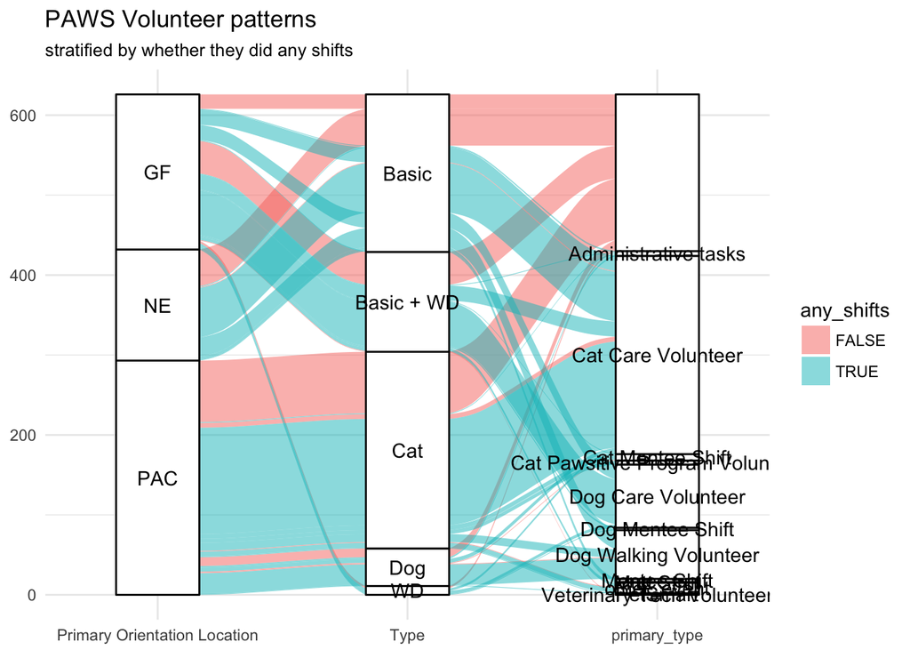

```r
signup_service_plot <- final_data %>%
  filter(Orientation.Date.Primary < "2018-05-01") %>%
  group_by(orient_loc.Primary, orient_type.Primary, primary_type, any_shifts) %>%
  summarise(Freq = n()) %>%
  ungroup()


ggplot(data = signup_service_plot,
       aes(axis1 = orient_loc.Primary, axis2 = orient_type.Primary, axis3 = primary_type,
           weight = Freq)) +
  scale_x_discrete(limits = c("Primary Orientation Location", "Type", "primary_type"), expand = c(.1, .05)) +
  geom_alluvium(aes(fill = any_shifts)) +
  geom_stratum() + geom_text(stat = "stratum", label.strata = TRUE) +
  theme_minimal() +
  ggtitle("PAWS Volunteer patterns",
          "stratified by whether they did any shifts")
```

OK - This is a start. It needs to be clarified a little.

How long since the last shift? This can help us decide a volunteer disengaged cutoff

```r
todays_date <- "2018-07-26"
final_data$total_time <- as.numeric(final_data$last_recorded_date - final_data$Orientation.Date.Primary)
final_data$time_to_first <- as.numeric(final_data$first_shift_date - final_data$Orientation.Date.Primary)
final_data$time_last_to_first <- as.numeric(final_data$last_recorded_date - final_data$first_shift_date)
final_data$days_since_last <- as.numeric(as.Date(todays_date) - final_data$last_recorded_date)

final_data$test_period <- case_when(
  final_data$Orientation.Date.Primary >= "2017-01-01" & final_data$Orientation.Date.Primary < "2017-05-01" ~ "2017",
  final_data$Orientation.Date.Primary >= "2018-01-01" & final_data$Orientation.Date.Primary < "2018-05-01" ~ "2018",
  TRUE ~ "other"
)
```

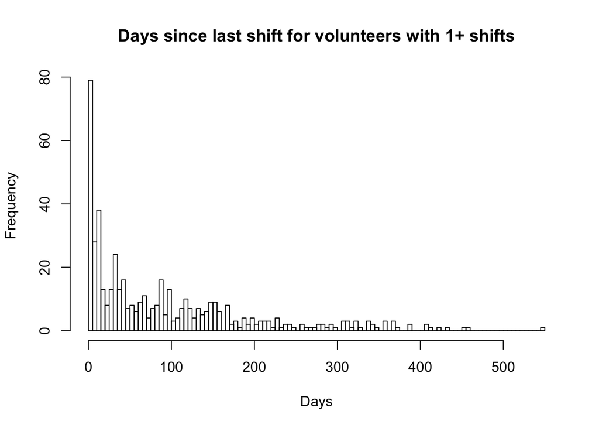

```r
model_data <- filter(final_data, total_shifts > 0)
hist(as.numeric(model_data$days_since_last), 100,
     main = "Days since last shift for volunteers with 1+ shifts",
     xlab = "Days")
```

```r
median_days_since <- median(filter(final_data, total_shifts > 0)$days_since_last)

median_days_between <- median(filter(final_data, total_shifts > 0)$time_bw_shifts, na.rm = T)
```

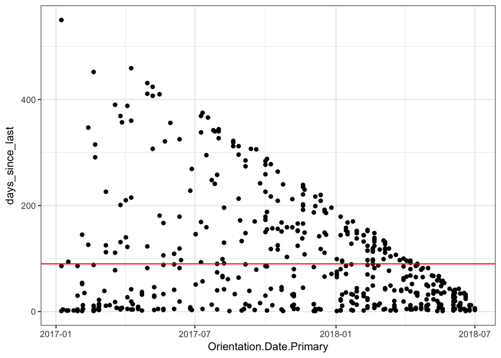

```r
ggplot(filter(final_data, total_shifts > 0), aes(x = Orientation.Date.Primary, y = days_since_last)) +
  geom_point() +
  geom_hline(yintercept = 90, color = "red") +
  theme_bw()
```

```r
# ggplot(filter(final_data, total_shifts > 0), aes(x = as.Date(todays_date) -Orientation.Date.Primary, y = days_since_last)) +
#   geom_point() +
#   geom_hline(yintercept = 90, color = "red") +
#   geom_abline(slope = 1, intercept = -90, color = "blue") +
#   theme_bw()
```

OK. Based on this plot, I propose to use >90 days (red line) as a cutoff for when a volunteer is disengaged. I will restrict to looking at data from volunteers who did orientation before a certain date (May 01 2018) because we don’t know if these volunteers will become disengaged.

## Summary stats

For volunteers:

- How many did orientation, but no shifts?
- How many did orientation, had only 1 shift?
- How many did orientation, had 2+ shifts?

We will define two test periods to compare:

- 2017: Orientation (primary) between Jan 01 2017 - May 01 2017
- 2018: Orientation (primary) between Jan 01 2018 - May 01 2018

To be a real comparison, we would need to only look at service data between Jan 01 and July 26 from both years as well.

Overall, it looks like more volunteers did orientation in 2018!

```r
end_summary <- final_data  %>%
  group_by(test_period) %>%
  summarise(total_volunteers = n(),
            volunteered_never = paste( round(100* sum(total_shifts==0)/n(),1) ,"%"),
            volunteered_onlyonce = paste( round(100* sum(total_shifts==1)/n(),1),"%"),
            twototen = paste( round(100* sum(total_shifts>=2 & total_shifts<10)/n(), 1), "%"),
            tenplus = paste( round(100* sum(total_shifts>=10)/n(), 1), "%"),
            ave_shifts = round( mean(total_shifts), 2),
            ave_missed_shifts = round( mean(missed_shifts), 2))

knitr::kable(t(end_summary), caption="Overall Summary")
```

Overall Summary

| test_period | 2017 | 2018 | other |
| --- | --- | --- | --- |
| total_volunteers | 101 | 201 | 425 |
| volunteered_never | 20.8 % | 22.9 % | 38.6 % |
| volunteered_onlyonce | 5.9 % | 13.9 % | 13.4 % |
| twototen | 23.8 % | 48.3 % | 29.6 % |
| tenplus | 49.5 % | 14.9 % | 18.4 % |
| ave_shifts | 24.33 | 5.12 | 5.86 |
| ave_missed_shifts | 0.51 | 0.10 | 0.18 |

# Output

I wrote files for downstream use.

- a Rds with merged data to Data/merged.Rds
- a Rds with cleaned service data to Data/service_clean.Rds

```r
saveRDS(final_data, "../../../Data/merged.Rds")
saveRDS(service_clean, "../../../Data/service_clean.Rds")
```